# Regression Interpretation

# Agenda

- Building models
- Interpretation in practice
- Logistic regression

# Learning objectives

By the end of the lecture, you will be able to …

- Build and compare nested OLS models to assess mediation and moderation.
- Compare coefficients across groups and predictors.
- Estimate, interpret, and communicate logistic regression results.

# Code-along 09

Download and open [code-along-09.qmd](https://www.dropbox.com/scl/fi/5ssfstlf05ofz27qej3t3/code-along-09.qmd?rlkey=tku7ens1lt8k4dlr2c6wy0zi7&st=ddlikz2o&dl=1)

## Packages

Load the standard packages.

```r
library(tidyverse)
library(haven) # not core tidyverse
library(gssr)
library(gssrdoc)
library(summarytools)
library(gtsummary)
library(modelbased)
library(modelsummary)
```

## Load your data

```r
# Load all gss
gss22 <- gss_get_yr(2022)
```

## Variables

- `realrinc` R’s personal income in constant $
- `lifenow` R’s rating of life overall now from 0-10
- `childs` Number of children
- `mntlhlth` Days of poor mental health past 30 days
- `age` R’s age
- `educ` R’s highest year of school completed
- `hrs1` Hours R worked last week
- `sex` R’s sex
- `marital` R’s marital status
- `wtssnrps_as` survey weights

Make a df with only the (pretty) categorical and continuous variables we’ll analyze.

```r
# Categorical Variables
my_cat <- gss22 |>
  select(id, sex, marital) |>
  zap_missing() |>
  mutate(
    sex = as_factor(sex),
    marital = as_factor(marital)) |>
  droplevels()

# Continuous Variables
my_con <- gss22 |>
  select(id, wtssnrps_as, age, educ, hrs1, realrinc, lifenow, childs, mntlhlth) |>
  mutate(across(c(age, educ, hrs1, realrinc, lifenow, childs, mntlhlth),
                as.numeric))

# Combine the two dataframes
my_data <- full_join(my_cat, my_con, by = c("id")) |>
  drop_na() |>
  mutate(
    marital = recode(
      marital,
      "married"       = "Married",
      "never married" = "Never married",
      "widowed"       = "Div/Wid/Sep",
      "divorced"      = "Div/Wid/Sep",
      "separated"     = "Div/Wid/Sep"),
    marital = factor(
      marital,
      levels = c("Never married", "Div/Wid/Sep", "Married")),
    income10k = realrinc / 10000
  )

remove(my_con) # clean up the Environment
remove(my_cat)

# show pretty labels in regression table
coef_labels <- c(
  age = "Age",
  sexfemale = "Female",
  "maritalDiv/Wid/Sep" = "Div/Wid/Sep (ref. = never married)",
  maritalMarried = "Married",
  childs = "Children",
  educ = "Education (years)",
  hrs1 = "Work hours",
  income10k = "Income ($10k)",
  mntlhlth = "Poor mental health days",
  lifenow = "Life satisfaction",
  "educ:income10k" = "Education × Income")
```

# Building Models

**Most analysts will run several models predicting a single outcome**  
(Model 1, Model 2, etc.)

**Why?**

- Elaborate on an apparent relationship between two variables
- Explore alternative (or competing) explanations
- Test whether apparent associations “hold up” under more stringent conditions

**Heads Up!**

Use the same sample (the same respondents) in every model you compare.

Several relationships may be present when a third variable (Z) is included in the analysis of two-variables.

**Confounders**  
The relationship between X and Y is spurious—both predicted by Z

**Covariates**  
Other variables in the model that predict Y, but mostly unrelated to the relationship between X and Y

**Moderators**  
The relationship between X and Y depends on Z (*interactions*).  
*Does a third variable change the relationship between X and Y?*

**Mediators**  
Explains the relationship between X and Y (X🡪Z🡪Y)  
*Does a third variable help explain the relationship between X and Y?*

## Mediators

[figure not shown]

## Conditions for mediation

1. IV🡪DV relationship is significant: `lm(DV ~ IV)`
2. IV🡪MV relationship is significant: `lm(CV ~ IV)`
3. MV🡪DV relationship is significant when IV is controlled: `lm(DV ~ IV + CV)`

**Heads Up!**

The IV🡪DV coefficient must be closer to zero when CV is controlled than when it is not (compare models 1 and 3).

Does income help explain the relationship between education and life satisfaction?

```r
models <- list(
  "Total Effect"  = lm(lifenow ~ educ, data = my_data),
  "Path A"        = lm(income10k ~ educ, data = my_data),
  "Direct Effect" = lm(lifenow ~ educ + income10k, data = my_data)
)

modelsummary(
  models,
  title         = "OLS Regression: Income as a Mediator (No Controls)",
  statistic     = "std.error",
  stars         = c("*" = .05, "**" = .01, "***" = .001),
  coef_rename   = coef_labels,
  gof_map       = c("nobs", "r.squared")
)
```

| OLS Regression: Income as a Mediator (No Controls) | OLS Regression: Income as a Mediator (No Controls) Total Effect | OLS Regression: Income as a Mediator (No Controls) Path A | OLS Regression: Income as a Mediator (No Controls) Direct Effect |
| --- | --- | --- | --- |
| (Intercept) | 6.425*** | -2.246*** | 6.629*** |
|  | (0.217) | (0.409) | (0.215) |
| Education (years) | 0.097*** | 0.357*** | 0.064*** |
|  | (0.015) | (0.027) | (0.015) |
| Income ($10k) |  |  | 0.091*** |
|  |  |  | (0.013) |
| Num.Obs. | 1628 | 1628 | 1628 |
| R2 | 0.026 | 0.094 | 0.055 |

* p < 0.05, ** p < 0.01, *** p < 0.001

lifenow (DV)  
educ (IV)  
income10k (MV)

Does income help explain the relationship between education and life satisfaction?

**Lesson 1:** Coefficients can change when a mediator is added.

- Education’s coefficient falls from 0.097 to 0.064
- About a 34% reduction

> $\frac{0.097 - 0.064}{0.097} \approx 0.34$
- Evidence of partial mediation: the direct effect shrinks but remains statistically significant (*p* < .001)

**Lesson 2:** Model fit can improve when theoretically important variables are included.

- $R^2$ increases from .026 to .055
- Income explains additional variation in life satisfaction beyond education alone

## Mediation in a Paper

Does income help explain the association between education and life satisfaction, net of controls?

```r
models_med <- list(
  "Model 1: Education"  = lm(lifenow ~ educ, data = my_data),
  "Model 2: + Controls" = lm(lifenow ~ educ + age + sex + marital + childs,
                             data = my_data),
  "Model 3: + Income"   = lm(lifenow ~ educ + age + sex + marital + childs
                             + income10k, data = my_data)
)

modelsummary(
  models_med,
  title = "OLS Regression of Life Satisfaction: Income as a Mediator, Net of Controls",
  statistic   = "std.error",
  stars       = c("*" = .05, "**" = .01, "***" = .001),
  coef_rename = coef_labels,
  gof_map     = c("nobs", "adj.r.squared")
)
```

| OLS Regression of Life Satisfaction: Income as a Mediator, Net of Controls | OLS Regression of Life Satisfaction: Income as a Mediator, Net of Controls Model 1: Education | OLS Regression of Life Satisfaction: Income as a Mediator, Net of Controls Model 2: + Controls | OLS Regression of Life Satisfaction: Income as a Mediator, Net of Controls Model 3: + Income |
| --- | --- | --- | --- |
| (Intercept) | 6.425*** | 5.790*** | 5.971*** |
|  | (0.217) | (0.239) | (0.241) |
| Education (years) | 0.097*** | 0.070*** | 0.050*** |
|  | (0.015) | (0.014) | (0.015) |
| Age |  | 0.017*** | 0.016*** |
|  |  | (0.003) | (0.003) |
| Female |  | 0.022 | 0.080 |
|  |  | (0.078) | (0.079) |
| Div/Wid/Sep (ref. = never married) |  | 0.017 | -0.012 |
|  |  | (0.122) | (0.121) |
| Married |  | 0.765*** | 0.686*** |
|  |  | (0.099) | (0.100) |
| Children |  | -0.041 | -0.038 |
|  |  | (0.028) | (0.028) |
| Income ($10k) |  |  | 0.060*** |
|  |  |  | (0.013) |
| Num.Obs. | 1628 | 1628 | 1628 |
| R2 Adj. | 0.026 | 0.099 | 0.109 |

* p < 0.05, ** p < 0.01, *** p < 0.001

## Moderation in a Paper

Does the association between education and life satisfaction depend on income?

```r
models_mod <- list(
  "Model 1: Education"     = lm(lifenow ~ educ, data = my_data),
  "Model 2: + Income & Controls" = lm(lifenow ~ educ + income10k + age + sex + marital + childs,
                                data = my_data),
  "Model 3: + Interaction" = lm(lifenow ~ educ * income10k + age + sex + marital + childs,
                                data = my_data)
)

modelsummary(
  models_mod,
  title = "OLS Regression of Life Satisfaction: Education × Income Interaction",
  statistic   = "std.error",
  stars       = c("*" = .05, "**" = .01, "***" = .001),
  coef_rename = coef_labels,
  gof_map     = c("nobs", "adj.r.squared")
)
```

| OLS Regression of Life Satisfaction: Education × Income Interaction | OLS Regression of Life Satisfaction: Education × Income Interaction Model 1: Education | OLS Regression of Life Satisfaction: Education × Income Interaction Model 2: + Income & Controls | OLS Regression of Life Satisfaction: Education × Income Interaction Model 3: + Interaction |
| --- | --- | --- | --- |
| (Intercept) | 6.425*** | 5.971*** | 6.217*** |
|  | (0.217) | (0.241) | (0.301) |
| Education (years) | 0.097*** | 0.050*** | 0.034 |
|  | (0.015) | (0.015) | (0.019) |
| Income ($10k) |  | 0.060*** | -0.041 |
|  |  | (0.013) | (0.075) |
| Age |  | 0.016*** | 0.016*** |
|  |  | (0.003) | (0.003) |
| Female |  | 0.080 | 0.079 |
|  |  | (0.079) | (0.079) |
| Div/Wid/Sep (ref. = never married) |  | -0.012 | -0.010 |
|  |  | (0.121) | (0.121) |
| Married |  | 0.686*** | 0.695*** |
|  |  | (0.100) | (0.100) |
| Children |  | -0.038 | -0.040 |
|  |  | (0.028) | (0.028) |
| Education × Income |  |  | 0.006 |
|  |  |  | (0.005) |
| Num.Obs. | 1628 | 1628 | 1628 |
| R2 Adj. | 0.026 | 0.109 | 0.110 |

* p < 0.05, ** p < 0.01, *** p < 0.001

## Moderation vs Mediation

|  | **Mediation** | **Moderation** |
| --- | --- | --- |
| **Question** | Does income help explain the relationship between education and life satisfaction? | Does the relationship between education and life satisfaction depend on income? |
| **Concept** | Income explains **why** education is associated with life satisfaction. | Income changes **how strongly** education is associated with life satisfaction. |
| **Model** | `lifenow ~ educ + controls` `income10k ~ educ + controls` `lifenow ~ educ + income10k + controls` | `lifenow ~ educ * income10k + controls` |
| **Look at** | Does the `educ` coefficient shrink when `income10k` is added? | Is the `educ:income10k` coefficient significant? |

Formal test of the indirect effect: `mediation::mediate()` or `lavaan::sem()`

## Theory-driven blocks

What predicts life satisfaction?

```r
models_blocks <- list(
  "Model 1: Demographic"   = lm(lifenow ~ age + sex + educ, data = my_data),
  "Model 2: + Family"      = lm(lifenow ~ age + sex + educ + marital + childs,
                                data = my_data),
  "Model 3: + Economic"    = lm(lifenow ~ age + sex + educ + marital + childs
                                + hrs1 + income10k, data = my_data),
  "Model 4: + Mental health" = lm(lifenow ~ age + sex + educ + marital + childs
                                + hrs1 + income10k + mntlhlth, data = my_data)
)

modelsummary(
  models_blocks,
  title = "OLS Regression of Life Satisfaction: Nested Blocks of Predictors",
  statistic   = "std.error",
  stars       = c("*" = .05, "**" = .01, "***" = .001),
  coef_rename = coef_labels,
  gof_map     = c("nobs", "adj.r.squared")
)
```

| OLS Regression of Life Satisfaction: Nested Blocks of Predictors | OLS Regression of Life Satisfaction: Nested Blocks of Predictors Model 1: Demographic | OLS Regression of Life Satisfaction: Nested Blocks of Predictors Model 2: + Family | OLS Regression of Life Satisfaction: Nested Blocks of Predictors Model 3: + Economic | OLS Regression of Life Satisfaction: Nested Blocks of Predictors Model 4: + Mental health |
| --- | --- | --- | --- | --- |
| (Intercept) | 5.687*** | 5.790*** | 6.177*** | 6.780*** |
|  | (0.242) | (0.239) | (0.269) | (0.256) |
| Age | 0.020*** | 0.017*** | 0.015*** | 0.008** |
|  | (0.003) | (0.003) | (0.003) | (0.003) |
| Female | -0.080 | 0.022 | 0.063 | 0.190* |
|  | (0.079) | (0.078) | (0.080) | (0.075) |
| Education (years) | 0.091*** | 0.070*** | 0.051*** | 0.048*** |
|  | (0.014) | (0.014) | (0.015) | (0.014) |
| Div/Wid/Sep (ref. = never married) |  | 0.017 | 0.006 | 0.009 |
|  |  | (0.122) | (0.122) | (0.114) |
| Married |  | 0.765*** | 0.689*** | 0.628*** |
|  |  | (0.099) | (0.100) | (0.094) |
| Children |  | -0.041 | -0.038 | -0.039 |
|  |  | (0.028) | (0.028) | (0.027) |
| Work hours |  |  | -0.005 | -0.004 |
|  |  |  | (0.003) | (0.003) |
| Income ($10k) |  |  | 0.064*** | 0.054*** |
|  |  |  | (0.013) | (0.013) |
| Poor mental health days |  |  |  | -0.068*** |
|  |  |  |  | (0.005) |
| Num.Obs. | 1628 | 1628 | 1628 | 1628 |
| R2 Adj. | 0.053 | 0.099 | 0.110 | 0.212 |

* p < 0.05, ** p < 0.01, *** p < 0.001

# Interpretation in Practice

## Comparing between models

Is education equally associated with life satisfaction for men and women?

```r
m_men <- lm(lifenow ~ educ + age + marital + childs + income10k,
            data = subset(my_data, sex == "male"))

m_women <- lm(lifenow ~ educ + age + marital + childs + income10k,
              data = subset(my_data, sex == "female"))

modelsummary(
  list("Men" = m_men, "Women" = m_women),
  title = "OLS Regression of Life Satisfaction: Separate Models by Gender",
  statistic   = "std.error",
  stars       = c("*" = .05, "**" = .01, "***" = .001),
  coef_rename = coef_labels,
  gof_map     = c("nobs", "adj.r.squared")
)
```

| OLS Regression of Life Satisfaction: Separate Models by Gender | OLS Regression of Life Satisfaction: Separate Models by Gender Men | OLS Regression of Life Satisfaction: Separate Models by Gender Women |
| --- | --- | --- |
| (Intercept) | 6.202*** | 5.813*** |
|  | (0.337) | (0.347) |
| Education (years) | 0.037 | 0.063** |
|  | (0.021) | (0.022) |
| Age | 0.015** | 0.017*** |
|  | (0.005) | (0.004) |
| Div/Wid/Sep (ref. = never married) | 0.034 | -0.039 |
|  | (0.186) | (0.160) |
| Married | 0.552*** | 0.809*** |
|  | (0.145) | (0.138) |
| Children | -0.029 | -0.040 |
|  | (0.040) | (0.041) |
| Income ($10k) | 0.072*** | 0.047* |
|  | (0.017) | (0.021) |
| Num.Obs. | 828 | 800 |
| R2 Adj. | 0.103 | 0.115 |

* p < 0.05, ** p < 0.01, *** p < 0.001

**You must formally test whether coefficients differ across models!**

Null hypothesis:

$$H_0: b_{educ,m}=b_{educ,w}$$

The coefficient difference test is:

$$z =
\frac{b_{educ,m}-b_{educ,w}}
{\sqrt{SE^2_{educ,m}+SE^2_{educ,w}}}$$

where:

$b_{educ,m}$ = education coefficient for men  
$b_{educ,w}$ = education coefficient for women

```r
z_test <- function(m1, m2, term, vc = vcov) {
  b1  <- unname(coef(m1)[term])
  b2  <- unname(coef(m2)[term])
  se1 <- sqrt(vc(m1)[term, term])
  se2 <- sqrt(vc(m2)[term, term])
  z   <- (b1 - b2) / sqrt(se1^2 + se2^2)
  c(b_1 = b1, b_2 = b2, diff = b1 - b2, z = z, p = 2 * pnorm(-abs(z)))
}

compare <- z_test(m_men, m_women, "educ")

compare
```

```
        b_1         b_2        diff           z           p
 0.03663939  0.06272784 -0.02608845 -0.86832804  0.38521477
```

**A package is safer than hand-coding the z-test: it estimates both models jointly and uses robust standard errors**

```r
# install.packages("remotes")
# remotes::install_github("tdmize/suest")

library(suest)
library(marginaleffects)

combined <- suest(m_men, m_women)

effects_groups <- marginaleffects::avg_comparisons(combined, variables = "educ",
                                  newdata = suest_newdata(combined))
effects_groups

marginaleffects::hypotheses(effects_groups, hypothesis = difference ~ revpairwise)
```

## Comparing between models

Education was positively and statistically significantly associated with life satisfaction among women (*b* = 0.063, *p* = .004) but not among men (*b* = 0.037, *p* = .080). However, a formal test showed that the two coefficients did not differ significantly (*p* = .385). The data therefore do not support the conclusion that education matters more for women’s life satisfaction than for men’s.

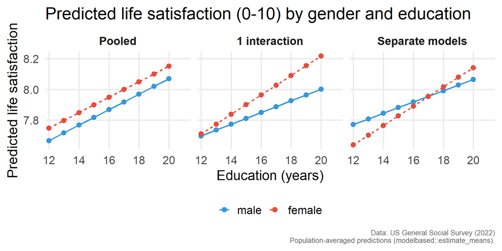

| Model Approach | Assumption |
| --- | --- |
| **Pooled** `lifenow ~ educ + sex + CVs, data = my_data` | Men and women differ only in the intercept. Every slope is the same. |
| **1 interaction** `lifenow ~ educ * sex + CVs, data = my_data` | `educ` slope differs by `sex`. All other slopes equal. |
| **Separate models** (or fully interacted model) `lifenow ~ educ + CVs, data = subset(my_data, sex == "male")` `lifenow ~ educ + CVs, data = subset(my_data, sex == "female")` | Every slope and the intercept can differ by sex. |

## Standardized regression coefficients

Is education or income more strongly associated with life satisfaction?

```r
mod_01 <- lm(lifenow ~ educ + income10k + sex + age + marital + childs,
            data = my_data)

mod_02 <- lm(lifenow ~ scale(educ) + scale(income10k) + sex + age + marital + childs,
            data = my_data)

modelsummary(
  list("Unstandardized" = mod_01, "Standardized" = mod_02),
  title = "OLS Regression of Life Satisfaction: Unstandardized and Standardized Coefficients",
  statistic   = "std.error",
  stars       = c("*" = .05, "**" = .01, "***" = .001),
  coef_rename = c(coef_labels,
                  "scale(educ)"      = "Education (years)",
                  "scale(income10k)" = "Income ($10k)"),
  gof_map     = c("nobs", "adj.r.squared")
)
```

For more information, see this [tutorial](https://murraylax.org/rtutorials/multregression_standardized.html)

| OLS Regression of Life Satisfaction: Unstandardized and Standardized Coefficients | OLS Regression of Life Satisfaction: Unstandardized and Standardized Coefficients Unstandardized | OLS Regression of Life Satisfaction: Unstandardized and Standardized Coefficients Standardized |
| --- | --- | --- |
| (Intercept) | 5.971*** | 6.886*** |
|  | (0.241) | (0.136) |
| Education (years) | 0.050*** | 0.139*** |
|  | (0.015) | (0.041) |
| Income ($10k) | 0.060*** | 0.191*** |
|  | (0.013) | (0.042) |
| Female | 0.080 | 0.080 |
|  | (0.079) | (0.079) |
| Age | 0.016*** | 0.016*** |
|  | (0.003) | (0.003) |
| Div/Wid/Sep (ref. = never married) | -0.012 | -0.012 |
|  | (0.121) | (0.121) |
| Married | 0.686*** | 0.686*** |
|  | (0.100) | (0.100) |
| Children | -0.038 | -0.038 |
|  | (0.028) | (0.028) |
| Num.Obs. | 1628 | 1628 |
| R2 Adj. | 0.109 | 0.109 |

* p < 0.05, ** p < 0.01, *** p < 0.001

## Standardized regression coefficients

**How much is 1 standard deviation change?**

```r
sd(my_data$educ)
```

```
[1] 2.757838
```

```r
sd(my_data$income10k) * 10000
```

```
[1] 32024.58
```

**Is the coefficient difference statistically significant?**

```r
V_std <- vcov(mod_02)
b_std <- coef(mod_02)
inc <- "scale(income10k)"
edu <- "scale(educ)"

std_diff <- unname(b_std[inc] - b_std[edu])
std_z    <- std_diff / sqrt(V_std[inc, inc] + V_std[edu, edu] - 2 * V_std[inc, edu])
std_p    <- 2 * pnorm(-abs(std_z))

round(c(diff = std_diff, z = std_z, p = std_p), 3)
```

```
 diff     z     p
0.052 0.781 0.435
```

## Standardized regression coefficients

Holding the other variables constant, a one-standard-deviation increase in education (2.8 years) is associated with a 0.14-point increase in life satisfaction, and a one-standard-deviation increase in income ($32,000) with a 0.19-point increase. Income is therefore somewhat more strongly associated with life satisfaction, but the difference is not statistically significant (*p* = .435).

## Survey weights

Weights let respondents who are under-represented in the survey compared with the population count more, and those who are over-represented count less.

```r
m_unwt <- lm(lifenow ~ educ + income10k + sex + age + marital + childs,
             data = my_data)

m_wt   <- lm(lifenow ~ educ + income10k + sex + age + marital + childs,
             data = my_data, weights = wtssnrps_as)

modelsummary(
  list("Unweighted" = m_unwt, "Weighted" = m_wt),
  title = "OLS Regression of Life Satisfaction: Unweighted and Weighted Estimates",
  statistic   = "std.error",
  stars       = c("*" = .05, "**" = .01, "***" = .001),
  coef_rename = coef_labels,
  gof_map     = c("nobs", "adj.r.squared")
)
```

| OLS Regression of Life Satisfaction: Unweighted and Weighted Estimates | OLS Regression of Life Satisfaction: Unweighted and Weighted Estimates Unweighted | OLS Regression of Life Satisfaction: Unweighted and Weighted Estimates Weighted |
| --- | --- | --- |
| (Intercept) | 5.971*** | 6.256*** |
|  | (0.241) | (0.219) |
| Education (years) | 0.050*** | 0.053*** |
|  | (0.015) | (0.014) |
| Income ($10k) | 0.060*** | 0.050*** |
|  | (0.013) | (0.012) |
| Female | 0.080 | 0.297*** |
|  | (0.079) | (0.075) |
| Age | 0.016*** | 0.007* |
|  | (0.003) | (0.003) |
| Div/Wid/Sep (ref. = never married) | -0.012 | 0.132 |
|  | (0.121) | (0.127) |
| Married | 0.686*** | 0.786*** |
|  | (0.100) | (0.098) |
| Children | -0.038 | -0.041 |
|  | (0.028) | (0.027) |
| Num.Obs. | 1628 | 1628 |
| R2 Adj. | 0.109 | 0.114 |

* p < 0.05, ** p < 0.01, *** p < 0.001

# Logistic Regression

## Logistic Regression

```r
# Dichotomize lifenow (0-10) at the sample mean
avg_life <- mean(my_data$lifenow)

my_data <- my_data |>
  mutate(sat_high = if_else(lifenow > avg_life, 1, 0))

# The two models
m_ols   <- lm(sat_high ~ educ + income10k + sex + age + marital + childs,
              data = my_data)
m_logit <- glm(sat_high ~ educ + income10k + sex + age + marital + childs,
               data = my_data, family = binomial)

modelsummary(
  list("OLS" = m_ols, "Logit" = m_logit),
  title = "OLS vs. Logistic Regression of Above-Average Life Satisfaction",
  statistic   = "std.error",
  stars       = c("*" = .05, "**" = .01, "***" = .001),
  coef_rename = coef_labels,
  gof_map     = c("nobs", "adj.r.squared")
)
```

| OLS vs. Logistic Regression of Above-Average Life Satisfaction | OLS vs. Logistic Regression of Above-Average Life Satisfaction OLS | OLS vs. Logistic Regression of Above-Average Life Satisfaction Logit |
| --- | --- | --- |
| (Intercept) | 0.210** | -1.435*** |
|  | (0.070) | (0.348) |
| Education (years) | 0.013** | 0.060** |
|  | (0.004) | (0.022) |
| Income ($10k) | 0.015*** | 0.101*** |
|  | (0.004) | (0.025) |
| Female | 0.009 | 0.050 |
|  | (0.023) | (0.114) |
| Age | 0.004*** | 0.018*** |
|  | (0.001) | (0.005) |
| Div/Wid/Sep (ref. = never married) | 0.001 | -0.050 |
|  | (0.035) | (0.166) |
| Married | 0.173*** | 0.815*** |
|  | (0.029) | (0.143) |
| Children | -0.011 | -0.050 |
|  | (0.008) | (0.040) |
| Num.Obs. | 1628 | 1628 |
| R2 Adj. | 0.082 |  |

* p < 0.05, ** p < 0.01, *** p < 0.001

Logit model is on the **log‑odds** scale:

$$\ln\!\left(\frac{p}{1-p}\right) = \beta_0 + \beta_1 \text{educ} + \dots$$

- Education: **b = 0.06**. Each extra year of schooling changes the *log odds* of above-average satisfaction by 0.06.
- The sign is easy to read (+ means more likely, − means less likely), but the size is hard to interpret.
- To get an interpretable size, convert to **odds** or **probabilities**.

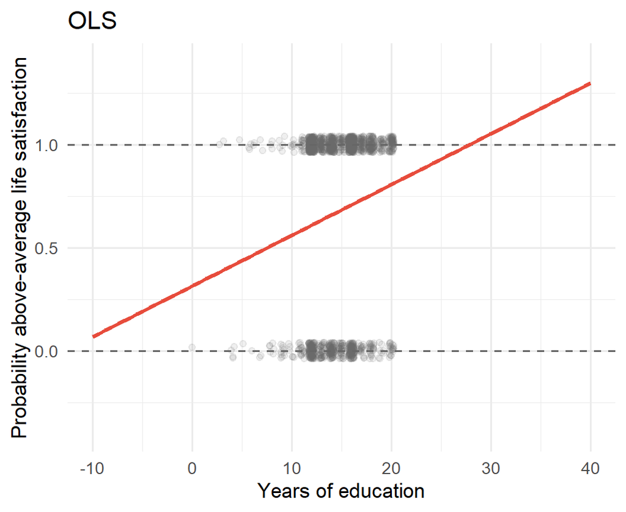

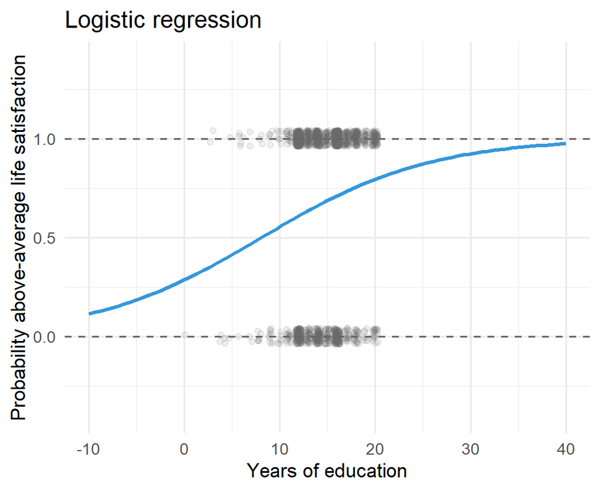

```r
m_logit <- glm(sat_high ~ educ + income10k + sex + age + marital + childs,
               data = my_data, family = binomial)

# Same model with different scales
modelsummary(
  list("Log odds"    = m_logit,
       "Odds ratios" = m_logit),
  exponentiate = c(FALSE, TRUE),
  title = "Logistic Regression of Above-Average Life Satisfaction: Log Odds and Odds Ratios",
  statistic   = "std.error",
  stars       = c("*" = .05, "**" = .01, "***" = .001),
  coef_rename = coef_labels,
  gof_map     = "nobs"
)
```

| Logistic Regression of Above-Average Life Satisfaction: Log Odds and Odds Ratios | Logistic Regression of Above-Average Life Satisfaction: Log Odds and Odds Ratios Log odds | Logistic Regression of Above-Average Life Satisfaction: Log Odds and Odds Ratios Odds ratios |
| --- | --- | --- |
| (Intercept) | -1.435*** | 0.238*** |
|  | (0.348) | (0.083) |
| Education (years) | 0.060** | 1.062** |
|  | (0.022) | (0.023) |
| Income ($10k) | 0.101*** | 1.107*** |
|  | (0.025) | (0.028) |
| Female | 0.050 | 1.051 |
|  | (0.114) | (0.119) |
| Age | 0.018*** | 1.018*** |
|  | (0.005) | (0.005) |
| Div/Wid/Sep (ref. = never married) | -0.050 | 0.951 |
|  | (0.166) | (0.158) |
| Married | 0.815*** | 2.259*** |
|  | (0.143) | (0.324) |
| Children | -0.050 | 0.951 |
|  | (0.040) | (0.038) |
| Num.Obs. | 1628 | 1628 |

* p < 0.05, ** p < 0.01, *** p < 0.001

$e^{0.06}$ = **1.062** (an *odds ratio*).

Each extra year of education multiplies the odds by 1.062, a **6.2%** change in the odds.

Married respondents’ odds of above-average life satisfaction are about **2.3** times those of never-married respondents, a **125.9%** increase in the odds.

- OR > 1 means higher odds
- OR < 1 means lower odds
- OR = 1 means no effect

## Log Odds, Odds, & Probabilities

| Step | Formula | Range |
| --- | --- | --- |
| Probability | $p$ | 0 to 1 |
| Odds | $p/(1-p)$ | 0 to ∞ |
| Log odds | $\ln(\text{odds})$ | −∞ to +∞ |
| **Back to odds** | $e^{b}$ |  |
| **Back to p** | $\text{odds}/(1+\text{odds})$ |  |

## Log Odds, Odds, & Probabilities

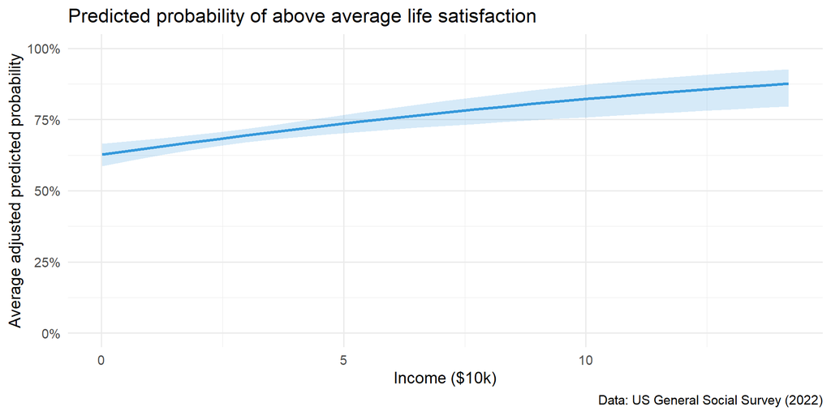

| Logistic Regression of Above-Average Life Satisfaction: Log Odds, Odds Ratios, and AMEs | Logistic Regression of Above-Average Life Satisfaction: Log Odds, Odds Ratios, and AMEs Log odds | Logistic Regression of Above-Average Life Satisfaction: Log Odds, Odds Ratios, and AMEs Odds ratios | Logistic Regression of Above-Average Life Satisfaction: Log Odds, Odds Ratios, and AMEs AME |
| --- | --- | --- | --- |
| (Intercept) | -1.435*** | 0.238*** |  |
|  | (0.348) | (0.083) |  |
| Education (years) | 0.060** | 1.062** | 0.012** |
|  | (0.022) | (0.023) | (0.004) |
| Income ($10k) | 0.101*** | 1.107*** | 0.020*** |
|  | (0.025) | (0.028) | (0.005) |
| Female | 0.050 | 1.051 | 0.010 |
|  | (0.114) | (0.119) | (0.023) |
| Age | 0.018*** | 1.018*** | 0.004*** |
|  | (0.005) | (0.005) | (0.001) |
| Div/Wid/Sep (ref. = never married) | -0.050 | 0.951 | -0.011 |
|  | (0.166) | (0.158) | (0.038) |
| Married | 0.815*** | 2.259*** | 0.164*** |
|  | (0.143) | (0.324) | (0.029) |
| Children | -0.050 | 0.951 | -0.010 |
|  | (0.040) | (0.038) | (0.008) |
| Num.Obs. | 1628 | 1628 | 1628 |

* p < 0.05, ** p < 0.01, *** p < 0.001

**Current best practice is to report AME in logit tables.**

On average, each extra year of education is associated with a **1.2 percentage-point** higher probability of above-average life satisfaction.

On average, married respondents’ probability of above-average life satisfaction is **16.4 percentage points** higher than never-married respondents’ (*p* < .001).

`marginaleffects::avg_slopes()`

## Bonus: Recommended Reading

[figure not shown]

Allison, Paul D. 1999. Multiple Regression: A Primer. Thousand Oaks, Calif: Pine Forge Press.

[Find it at the library](https://librarysearch.library.utoronto.ca/permalink/01UTORONTO_INST/1dl2m71/alma991106321724806196)